# cca

# 6 CCA sp terricole avec simplification de la granulo

Limon = limon fin + limon grossier Sable = sable fin + sable grossier

```r
granulo <- granulo_simple
Granulo <- granulo[,2:4]
```

```r
spe <- terricole
# le "." signifie contre toutes les var env; 1 : signifie aucune var env
spe.cca <- cca(spe ~ ., Granulo)
summary(spe.cca) # Scaling 2 (default)
```

```
##
## Call:
## cca(formula = spe ~ Argile + Limon + Sable, data = Granulo)
##
## Partitioning of scaled Chi-square:
##               Inertia Proportion
## Total          2.7755     1.0000
## Constrained    0.5803     0.2091
## Unconstrained  2.1953     0.7909
##
## Eigenvalues, and their contribution to the scaled Chi-square
##
## Importance of components:
##                          CCA1    CCA2    CCA3    CA1    CA2    CA3     CA4
## Eigenvalue            0.27207 0.17038 0.13781 0.3648 0.3393 0.3027 0.25848
## Proportion Explained  0.09802 0.06138 0.04965 0.1314 0.1223 0.1091 0.09313
## Cumulative Proportion 0.09802 0.15941 0.20906 0.3405 0.4628 0.5718 0.66495
##                           CA5     CA6     CA7     CA8     CA9    CA10    CA11
## Eigenvalue            0.20478 0.16588 0.15334 0.13355 0.10715 0.08743 0.07780
## Proportion Explained  0.07378 0.05977 0.05525 0.04812 0.03861 0.03150 0.02803
## Cumulative Proportion 0.73873 0.79850 0.85375 0.90186 0.94047 0.97197 1.00000
##
## Accumulated constrained eigenvalues
## Importance of components:
##                         CCA1   CCA2   CCA3
## Eigenvalue            0.2721 0.1704 0.1378
## Proportion Explained  0.4689 0.2936 0.2375
## Cumulative Proportion 0.4689 0.7625 1.0000
##
## Scaling 2 for species and site scores
## * Species are scaled proportional to eigenvalues
## * Sites are unscaled: weighted dispersion equal on all dimensions
##
##
## Species scores
##
##                                CCA1      CCA2       CCA3      CA1      CA2
## Andrena bicolor            0.395775 -0.341758 -0.0485038  0.03972 -0.46702
## Andrena carantonica       -0.911682 -0.640852 -0.3105500  1.71082  1.26840
## Andrena chrysosceles       1.513602 -0.474740 -0.1396639  1.06479 -1.48777
```

[output cut: 183 more lines]

```
## Parc Bonaert                    -1.47391
## Parc du Beffroi                  0.04527
## Parc du bois de Mons             0.92119
## Rue de l'Egalite                 1.15802
## Siege social                    -0.45251
## Stievenart                       0.25452
## Village des abeilles             1.12102
##
##
## Biplot scores for constraining variables
##
##           CCA1    CCA2     CCA3 CA1 CA2 CA3
## Argile  0.7123  0.6440  0.27911   0   0   0
## Limon   0.2372  0.9706  0.04018   0   0   0
## Sable  -0.3491 -0.9319 -0.09811   0   0   0
```

```r
# Unadjusted and adjusted R^2 - like statistics
RsquareAdj(spe.cca)
```

```
## $r.squared
## [1] 0.2090595
##
## $adj.r.squared
## [1] -0.004809424
```

Le jardin suspend est le site avec le % de sable le plus faible, pourtant il se trouve très proche de l’axe sable. Le Stivenart a quasiment la même texture, mais il se trouve à l’opposé, cela signifie que malgré la texture du sol les populations sont très différentes ? La diversité beta entre les deux site est de 0.45 (données abondance non raréfié) ce qui n’est pas énorme par rapport aux autres sites

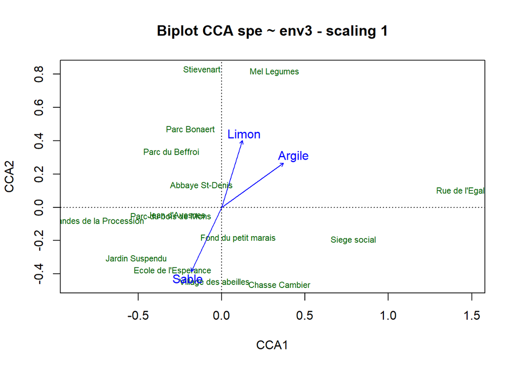

```r
# CCA scaling 1 biplot without species (using lc site scores)
plot(spe.cca,
scaling = 1,
display = c("lc", "cn"),
main = "Biplot CCA spe ~ env3 - scaling 1"
)
```

# 7 toutes les abeilles vs granulo simple R² = 0.182416

```r
spe <- data_bee_sp
# le "." signifie contre toutes les var env; 1 : signifie aucune var env
spe.cca <- cca(spe ~ ., Granulo)
summary(spe.cca) # Scaling 2 (default)
```

```
##
## Call:
## cca(formula = spe ~ Argile + Limon + Sable, data = Granulo)
##
## Partitioning of scaled Chi-square:
##               Inertia Proportion
## Total          2.0139     1.0000
## Constrained    0.3674     0.1824
## Unconstrained  1.6465     0.8176
##
## Eigenvalues, and their contribution to the scaled Chi-square
##
## Importance of components:
##                          CCA1    CCA2    CCA3    CA1    CA2    CA3     CA4
## Eigenvalue            0.14879 0.13142 0.08715 0.3286 0.2672 0.2299 0.17586
## Proportion Explained  0.07388 0.06526 0.04328 0.1632 0.1327 0.1142 0.08732
## Cumulative Proportion 0.07388 0.13914 0.18242 0.3456 0.4783 0.5924 0.67976
##                           CA5     CA6     CA7     CA8     CA9    CA10    CA11
## Eigenvalue            0.15880 0.11086 0.10554 0.08196 0.07482 0.05884 0.05410
## Proportion Explained  0.07885 0.05505 0.05241 0.04070 0.03715 0.02922 0.02687
## Cumulative Proportion 0.75861 0.81366 0.86607 0.90676 0.94392 0.97313 1.00000
##
## Accumulated constrained eigenvalues
## Importance of components:
##                         CCA1   CCA2    CCA3
## Eigenvalue            0.1488 0.1314 0.08715
## Proportion Explained  0.4050 0.3577 0.23724
## Cumulative Proportion 0.4050 0.7628 1.00000
##
## Scaling 2 for species and site scores
## * Species are scaled proportional to eigenvalues
## * Sites are unscaled: weighted dispersion equal on all dimensions
##
##
## Species scores
##
##                               CCA1      CCA2     CCA3      CA1       CA2
## Andrena bicolor            0.37330  0.017425 -0.20026  0.74589  0.952952
## Andrena carantonica       -0.07343  0.356033  0.46983  1.05396 -1.780266
## Andrena chrysosceles       0.75560 -1.513050 -0.13041  3.22473  1.342169
```

[output cut: 245 more lines]

```
## Parc Bonaert                 0.08189
## Parc du Beffroi              0.25456
## Parc du bois de Mons         0.31941
## Rue de l'Egalite            -0.77819
## Siege social                 0.37619
## Stievenart                   0.37631
## Village des abeilles         1.33471
##
##
## Biplot scores for constraining variables
##
##           CCA1    CCA2    CCA3 CA1 CA2 CA3
## Argile -0.4411 -0.7056 -0.5546   0   0   0
## Limon  -0.8866 -0.3867 -0.2537   0   0   0
## Sable   0.8175  0.4696  0.3334   0   0   0
```

```r
# Unadjusted and adjusted R^2 - like statistics
RsquareAdj(spe.cca)
```

```
## $r.squared
## [1] 0.182416
##
## $adj.r.squared
## [1] -0.03897073
```

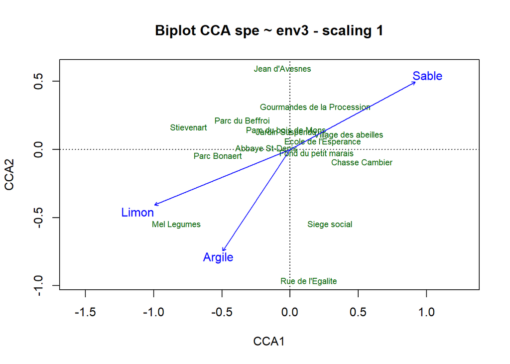

```r
# CCA scaling 1 biplot without species (using lc site scores)
plot(spe.cca,
scaling = 1,
display = c("lc", "cn"),
main = "Biplot CCA spe ~ env3 - scaling 1"
)
```

# Conclusion Centrer/réduire ne change rien, les espèces terricoles augmentent le R², utiliser moins de variables réduit le R².